# tutorial-population-weighted-temperature

This notebook will provide you guidance on how to access and use the [https://data.earthdatahub.destine.eu/era5/reanalysis-era5-single-levels-v0.zarr](https://earthdatahub.destine.eu/collections/era5/datasets/reanalysis-era5-single-levels) dataset on Earth Data Hub, together with the Hybrid gridded demographic data for the world dataset [https://data.earthdatahub.destine.eu/derived-GPWv4-Histsoc/demographics-hybrid-1950-2020-15-min-v0](https://earthdatahub.destine.eu/collections/derived-GPWv4-Histsoc/datasets/demographics-hybrid-1950-2020-15-min).

ERA5 single level data contains variables describing the global climate and weather for the past 8 decades. Data is available from 1940 onwards on a regular lat-lon grid of 0.25 degrees.

The Hybrid gridded demographic totals for the world contains the 1950-2020 demographic given as 5-year population bands at a 0.25 degree grid resolution.

### Goal of this tutorial

The goal of this tutorial is to visualize the area-averaged temperature in Europe as a function of time, and compare it with the population-averaged temperature.

### What you will learn:

- how to access the data
- select and reduce the data
- use different datasets together
- plot the results

To access datasets on [Earth Data Hub](https://earthdatahub.destine.eu) (EDH) you need to instruct your tools (xarray, Zarr, etc.) to use EDH personal access token when downloading the data.

To obtain a personal access token you first need to register to the [Destination Earth platform](https://platform.destine.eu) platform. Then you can go to [Earth Data Hub account settings](https://earthdatahub.destine.eu/account-settings) where you can find your default personal access token or create others. After retrieving your personal access token, please cut and paste it below: ⤵

```python
PAT = "your_personal_access_token"

# e.g. PAT="edh_pat_44bbb7e9192a4c6bb47ddf07d07564eee5d17de8dfc48f7118f88e3bc4a4157f8fe2403f5aa0a2d53441b6922ea9a33a"
```

### Working with EDH data

Datasets on Earth Data Hub are often very large and remotely hosted. Typical use imply a selection of the data followed by one or more reduction steps to be performed in a local or distributed Dask environment.

The structure of a workflow that uses EDH data tipically looks like this:

- data access
- data selection
- (optional) data reduction
- data download
- further operations and visualization

[Xarray](https://docs.xarray.dev/en/stable) and [Dask](https://www.dask.org) work together following a lazy principle. This means that when you access and manipulate a Zarr store the data is in not immediately downloaded and loaded in memory. Instead, Dask constructs a task graph that represents the operations to be performed. A smart user will first reduce the amount of data that needs to be downloaded and explicitly call `compute()` on it. Once the `compute()` operation is complete the data is loaded into memory and available for subsequent fast processing.

### Preparing the population data

#### 1. Data access

To access the data, only the dataset metadata must be downloaded. Xarray does this automatically when you access a Zarr dataset.

```python
import xarray as xr

world_population = xr.open_dataset(
    "https://hedp-data.bopen.eu/public/derived-GPWv4-Histsoc/demographics-hybrid-1950-2020-15-min-v0",
    chunks={},
    engine="zarr",
)
world_population = world_population.demographic_totals
world_population
```

```
<xarray.DataArray 'demographic_totals' (latitude: 720, longitude: 1440,
                                        age_band_lower_bound: 14, year: 71)> Size: 4GB
dask.array<open_dataset-demographic_totals, shape=(720, 1440, 14, 71), dtype=float32, chunksize=(64, 64, 14, 71), chunktype=numpy.ndarray>
Coordinates:
  * age_band_lower_bound  (age_band_lower_bound) int64 112B 0 5 10 ... 55 60 65
  * latitude              (latitude) float64 6kB 90.0 89.75 ... -89.5 -89.75
  * longitude             (longitude) float64 12kB 0.0 0.25 0.5 ... 359.5 359.8
  * year                  (year) int64 568B 1950 1951 1952 ... 2018 2019 2020
```

The longitude of the dataset is set from 0 to 360 degrees, which makes it uncomfortable to deal with data in the European area when using xarray:

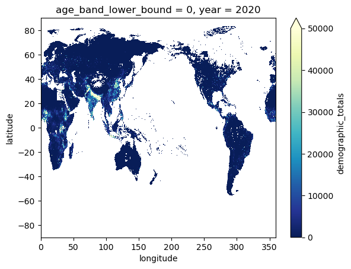

```python
world_population.sel(age_band_lower_bound=0, year=2020).plot(vmax=50_000, cmap="YlGnBu_r")
```

We can roll the longitude to a -180 to 180 extent:

```python
xr.set_options(keep_attrs=True)

world_population = world_population.assign_coords(longitude=(((world_population.longitude + 180) % 360) - 180))
world_population = world_population.roll(longitude=int(len(world_population.longitude) / 2), roll_coords=True)
world_population
```

```
<xarray.DataArray 'demographic_totals' (latitude: 720, longitude: 1440,
                                        age_band_lower_bound: 14, year: 71)> Size: 4GB
dask.array<rechunk-merge, shape=(720, 1440, 14, 71), dtype=float32, chunksize=(64, 64, 14, 71), chunktype=numpy.ndarray>
Coordinates:
  * age_band_lower_bound  (age_band_lower_bound) int64 112B 0 5 10 ... 55 60 65
  * latitude              (latitude) float64 6kB 90.0 89.75 ... -89.5 -89.75
  * year                  (year) int64 568B 1950 1951 1952 ... 2018 2019 2020
  * longitude             (longitude) float64 12kB -180.0 -179.8 ... 179.5 179.8
```

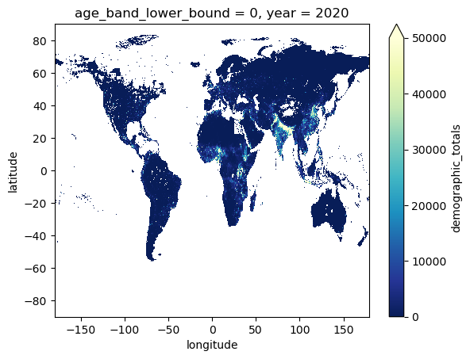

```python
world_population.sel(age_band_lower_bound=0, year=2020).plot(vmax=50_000, cmap="YlGnBu_r")
```

#### 2. Data selection

On the world data, we perform a geographical selection corresponding to continental Europe:

```python
europe_population = world_population.sel(latitude=slice(71, 36), longitude=slice(-10,35))
europe_population
```

```
<xarray.DataArray 'demographic_totals' (latitude: 141, longitude: 181,
                                        age_band_lower_bound: 14, year: 71)> Size: 101MB
dask.array<getitem, shape=(141, 181, 14, 71), dtype=float32, chunksize=(64, 64, 14, 71), chunktype=numpy.ndarray>
Coordinates:
  * age_band_lower_bound  (age_band_lower_bound) int64 112B 0 5 10 ... 55 60 65
  * latitude              (latitude) float64 1kB 71.0 70.75 70.5 ... 36.25 36.0
  * year                  (year) int64 568B 1950 1951 1952 ... 2018 2019 2020
  * longitude             (longitude) float64 1kB -10.0 -9.75 ... 34.75 35.0
```

This is a relatively small dataset, we don't need to worry too much about the download size.

#### 3. Data reduction

Next, we calculate the total population for each and every year. Notice that the data spans fron 1950 to 2020.

```python
europe_population_bands_total = europe_population.sum("age_band_lower_bound")
europe_population_bands_total
```

```
<xarray.DataArray 'demographic_totals' (latitude: 141, longitude: 181, year: 71)> Size: 7MB
dask.array<sum-aggregate, shape=(141, 181, 71), dtype=float32, chunksize=(64, 64, 71), chunktype=numpy.ndarray>
Coordinates:
  * latitude   (latitude) float64 1kB 71.0 70.75 70.5 70.25 ... 36.5 36.25 36.0
  * year       (year) int64 568B 1950 1951 1952 1953 ... 2017 2018 2019 2020
  * longitude  (longitude) float64 1kB -10.0 -9.75 -9.5 ... 34.5 34.75 35.0
```

#### 4. Data download

This is the phase where we explicitly trigger the download of the data. To do so we will call `compute()` on the European total population. The result will be small enought to easily fit into memory. Remember to assign the return of the `compute()` function to a new variable, so that the data is kept in memory.

We can measure the time it takes:

```python
%%time

europe_population_bands_total_computed = europe_population_bands_total.compute()
```

```
CPU times: user 874 ms, sys: 255 ms, total: 1.13 s
Wall time: 865 ms
```

### Preparing ERA5-single levels data

We will now follow the same logic to load ERA5 single levels data.

```python
era5_single_levels = xr.open_dataset(
    f"https://edh:{PAT}@data.earthdatahub.destine.eu/era5/reanalysis-era5-single-levels-v0.zarr",
    chunks={},
    engine="zarr",
    storage_options={"client_kwargs": {"trust_env": True}},
)
era5_single_levels
```

```
<xarray.Dataset> Size: 256TB
Dimensions:           (valid_time: 742824, latitude: 721, longitude: 1440)
Coordinates:
    entireAtmosphere  float32 4B ...
  * latitude          (latitude) float64 6kB 90.0 89.75 89.5 ... -89.75 -90.0
  * longitude         (longitude) float64 12kB 0.0 0.25 0.5 ... 359.5 359.8
    number            int64 8B ...
    surface           float64 8B ...
  * valid_time        (valid_time) datetime64[ns] 6MB 1940-01-01 ... 2024-09-...
Data variables: (12/83)
    alnid             (valid_time, latitude, longitude) float32 3TB dask.array<chunksize=(4320, 64, 64), meta=np.ndarray>
    alnip             (valid_time, latitude, longitude) float32 3TB dask.array<chunksize=(4320, 64, 64), meta=np.ndarray>
    aluvd             (valid_time, latitude, longitude) float32 3TB dask.array<chunksize=(4320, 64, 64), meta=np.ndarray>
    aluvp             (valid_time, latitude, longitude) float32 3TB dask.array<chunksize=(4320, 64, 64), meta=np.ndarray>
    blh               (valid_time, latitude, longitude) float32 3TB dask.array<chunksize=(4320, 64, 64), meta=np.ndarray>
    cdir              (valid_time, latitude, longitude) float32 3TB dask.array<chunksize=(4320, 64, 64), meta=np.ndarray>
    ...                ...
    viiwe             (valid_time, latitude, longitude) float32 3TB dask.array<chunksize=(4320, 64, 64), meta=np.ndarray>
    viiwn             (valid_time, latitude, longitude) float32 3TB dask.array<chunksize=(4320, 64, 64), meta=np.ndarray>
    vilwd             (valid_time, latitude, longitude) float32 3TB dask.array<chunksize=(4320, 64, 64), meta=np.ndarray>
    vilwe             (valid_time, latitude, longitude) float32 3TB dask.array<chunksize=(4320, 64, 64), meta=np.ndarray>
    vilwn             (valid_time, latitude, longitude) float32 3TB dask.array<chunksize=(4320, 64, 64), meta=np.ndarray>
    z                 (valid_time, latitude, longitude) float32 3TB dask.array<chunksize=(4320, 64, 64), meta=np.ndarray>
Attributes:
    Conventions:             CF-1.7
    GRIB_centre:             ecmf
    GRIB_centreDescription:  European Centre for Medium-Range Weather Forecasts
    GRIB_edition:            1
    GRIB_subCentre:          0
    history:                 2024-10-02T12:52 GRIB to CDM+CF via cfgrib-0.9.1...
    institution:             European Centre for Medium-Range Weather Forecasts
```

From the dataset we extract the 2 metre temperature:

```python
t2m = era5_single_levels.t2m - 273.15 # to celsius
t2m.attrs["units"] = "°C"
t2m
```

```
<xarray.DataArray 't2m' (valid_time: 742824, latitude: 721, longitude: 1440)> Size: 3TB
dask.array<sub, shape=(742824, 721, 1440), dtype=float32, chunksize=(4320, 64, 64), chunktype=numpy.ndarray>
Coordinates:
    entireAtmosphere  float32 4B ...
  * latitude          (latitude) float64 6kB 90.0 89.75 89.5 ... -89.75 -90.0
  * longitude         (longitude) float64 12kB 0.0 0.25 0.5 ... 359.5 359.8
    number            int64 8B ...
    surface           float64 8B ...
  * valid_time        (valid_time) datetime64[ns] 6MB 1940-01-01 ... 2024-09-...
Attributes: (12/31)
    GRIB_NV:                                  0
    GRIB_Nx:                                  1440
    GRIB_Ny:                                  721
    GRIB_cfName:                              unknown
    GRIB_cfVarName:                           t2m
    GRIB_dataType:                            an
    ...                                       ...
    GRIB_typeOfLevel:                         surface
    GRIB_units:                               K
    last_restart_dim_updated:                 742824
    long_name:                                2 metre temperature
    standard_name:                            unknown
    units:                                    °C
```

We perform the same coordinate rolling as we did before:

```python
t2m = t2m.assign_coords(longitude=(((t2m.longitude + 180) % 360) - 180))
t2m = t2m.roll(longitude=int(len(t2m.longitude) / 2), roll_coords=True)
t2m
```

```
<xarray.DataArray 't2m' (valid_time: 742824, latitude: 721, longitude: 1440)> Size: 3TB
dask.array<rechunk-merge, shape=(742824, 721, 1440), dtype=float32, chunksize=(4320, 64, 64), chunktype=numpy.ndarray>
Coordinates:
    entireAtmosphere  float32 4B ...
  * latitude          (latitude) float64 6kB 90.0 89.75 89.5 ... -89.75 -90.0
    number            int64 8B ...
    surface           float64 8B ...
  * valid_time        (valid_time) datetime64[ns] 6MB 1940-01-01 ... 2024-09-...
  * longitude         (longitude) float64 12kB -180.0 -179.8 ... 179.5 179.8
Attributes: (12/31)
    GRIB_NV:                                  0
    GRIB_Nx:                                  1440
    GRIB_Ny:                                  721
    GRIB_cfName:                              unknown
    GRIB_cfVarName:                           t2m
    GRIB_dataType:                            an
    ...                                       ...
    GRIB_typeOfLevel:                         surface
    GRIB_units:                               K
    last_restart_dim_updated:                 742824
    long_name:                                2 metre temperature
    standard_name:                            unknown
    units:                                    °C
```

Also, we perform a geographical selection corresponding to continental Europe and a temporal selection of the years between 1950 and 2020.

```python
t2m_europe = t2m.sel(latitude=slice(71, 36), longitude=slice(-10,35))
t2m_europe_1950_2020 = t2m_europe.sel(valid_time=slice("1950", "2020"))
t2m_europe_1950_2020
```

```
<xarray.DataArray 't2m' (valid_time: 622392, latitude: 141, longitude: 181)> Size: 64GB
dask.array<getitem, shape=(622392, 141, 181), dtype=float32, chunksize=(4320, 64, 64), chunktype=numpy.ndarray>
Coordinates:
    entireAtmosphere  float32 4B ...
  * latitude          (latitude) float64 1kB 71.0 70.75 70.5 ... 36.5 36.25 36.0
    number            int64 8B ...
    surface           float64 8B ...
  * valid_time        (valid_time) datetime64[ns] 5MB 1950-01-01 ... 2020-12-...
  * longitude         (longitude) float64 1kB -10.0 -9.75 -9.5 ... 34.75 35.0
Attributes: (12/31)
    GRIB_NV:                                  0
    GRIB_Nx:                                  1440
    GRIB_Ny:                                  721
    GRIB_cfName:                              unknown
    GRIB_cfVarName:                           t2m
    GRIB_dataType:                            an
    ...                                       ...
    GRIB_typeOfLevel:                         surface
    GRIB_units:                               K
    last_restart_dim_updated:                 742824
    long_name:                                2 metre temperature
    standard_name:                            unknown
    units:                                    °C
```

The ERA5 single levels dataset is way bigger than the population one. When we access a sample of the 2 metre temperature, xarray must download every chunk that includes a portion of the selected data.

To estimate the size of the download, we can use the `costing.py` module. This estimate must be done before we apply any reduction operation.

```python
import costing

costing.estimate_download_size(t2m, t2m_europe_1950_2020)
```

```
estimated_needed_chunks: 1740
estimated_memory_size: 123.155 GB
estimated_download_size: 12.316 GB
```

This amount of data could be easily downloaded from Earth Data Hub, thanks to data compression. However, the result of the `compute()` wouldn't fit into memory. We thus perform a reduction operation before triggering the download and computation, which greatly reduces the size of the result that will be kept in memory.

We compute the annual average of the 2 metre temperature:

```python
t2m_europe_yearly_mean = t2m_europe_1950_2020.resample(valid_time="YS").mean()
t2m_europe_yearly_mean
```

```
<xarray.DataArray 't2m' (valid_time: 71, latitude: 141, longitude: 181)> Size: 7MB
dask.array<transpose, shape=(71, 141, 181), dtype=float32, chunksize=(1, 64, 64), chunktype=numpy.ndarray>
Coordinates:
    entireAtmosphere  float32 4B ...
  * latitude          (latitude) float64 1kB 71.0 70.75 70.5 ... 36.5 36.25 36.0
    number            int64 8B ...
    surface           float64 8B ...
  * longitude         (longitude) float64 1kB -10.0 -9.75 -9.5 ... 34.75 35.0
  * valid_time        (valid_time) datetime64[ns] 568B 1950-01-01 ... 2020-01-01
Attributes: (12/31)
    GRIB_NV:                                  0
    GRIB_Nx:                                  1440
    GRIB_Ny:                                  721
    GRIB_cfName:                              unknown
    GRIB_cfVarName:                           t2m
    GRIB_dataType:                            an
    ...                                       ...
    GRIB_typeOfLevel:                         surface
    GRIB_units:                               K
    last_restart_dim_updated:                 742824
    long_name:                                2 metre temperature
    standard_name:                            unknown
    units:                                    °C
```

At this point, the resulting dataset small enough to call `compute()` on it. Remember to assign the return of the `compute()` function to a new variable, so that the data is kept in memory.

We can measure the time it takes:

```python
%%time

t2m_europe_yearly_mean_computed = t2m_europe_yearly_mean.compute()
```

```
CPU times: user 19min 36s, sys: 5min 31s, total: 25min 7s
Wall time: 8min 59s
```

### Area-weighted 2 metre temperature vs population-weighted 2 metre temperature

To compute the area-weighted 2 metre temperature trend in Europe, we need to spatially average the temperature data using the areas of the latitude-longitude grid cells as weights:

```python
import numpy as np

weights = np.cos(np.deg2rad(t2m_europe_yearly_mean_computed.latitude))
weights.name = "weights"

t2m_europe_yearly_mean_area_weighted = t2m_europe_yearly_mean_computed.weighted(weights).mean(("longitude", "latitude"))
t2m_europe_yearly_mean_area_weighted
```

```
<xarray.DataArray 't2m' (valid_time: 71)> Size: 568B
array([ 9.73143245,  9.54077568,  9.30266422,  9.65744633,  9.14167472,
        9.19113411,  8.39374605,  9.56572026,  9.29620918,  9.78678239,
        9.63911762,  9.99801575,  9.05815576,  8.92954205,  9.29800933,
        8.8260963 ,  9.29124349,  9.59479709,  9.21513626,  8.96015133,
        9.25737186,  9.33365114,  9.48211979,  9.33031631,  9.75456766,
        9.86438628,  9.00002637,  9.37511701,  8.84580254,  9.11709609,
        8.87549476,  9.29087939,  9.65754524,  9.7386082 ,  9.44506196,
        8.77296716,  9.2368825 ,  8.87974788,  9.69230407, 10.37366402,
       10.38624748,  9.59619789,  9.82628151,  9.38199912, 10.123129  ,
        9.89640215,  9.20763148,  9.88151595,  9.81225687, 10.29441204,
       10.41770865, 10.06531496, 10.3884738 , 10.31476037, 10.12192511,
       10.08604738, 10.41532098, 10.57369915, 10.46482174, 10.37075119,
        9.66206254, 10.51831596, 10.11687097, 10.28761378, 10.97883414,
       10.86744654, 10.65587192, 10.60293839, 10.90643005, 10.8906737 ,
       11.19913625])
Coordinates:
    entireAtmosphere  float32 4B 0.0
    number            int64 8B 0
    surface           float64 8B 0.0
  * valid_time        (valid_time) datetime64[ns] 568B 1950-01-01 ... 2020-01-01
Attributes: (12/31)
    GRIB_NV:                                  0
    GRIB_Nx:                                  1440
    GRIB_Ny:                                  721
    GRIB_cfName:                              unknown
    GRIB_cfVarName:                           t2m
    GRIB_dataType:                            an
    ...                                       ...
    GRIB_typeOfLevel:                         surface
    GRIB_units:                               K
    last_restart_dim_updated:                 742824
    long_name:                                2 metre temperature
    standard_name:                            unknown
    units:                                    °C
```

To compute the population-weighted 2 metre temperature we will follow the same logic, but this time we will use the population data as weight. To make the population data and temperature data compatible we need to transform the `valid_time` coordinate of the temperature data to the `year`coordinate of the population data so that the two data array can be easily multiplied:

```python
# shorten the names and replace the valid_time coordiate
temperature = t2m_europe_yearly_mean_computed.assign_coords({"year" : t2m_europe_yearly_mean_computed.valid_time.dt.year}).swap_dims({"valid_time": "year"}).drop_vars("valid_time")
population = europe_population_bands_total_computed

# compute the population wheighted temperature
t2m_europe_yearly_mean_population_weighted = (temperature * population).sum(dim=["latitude", "longitude"]) / population.sum(dim=["latitude", "longitude"])
```

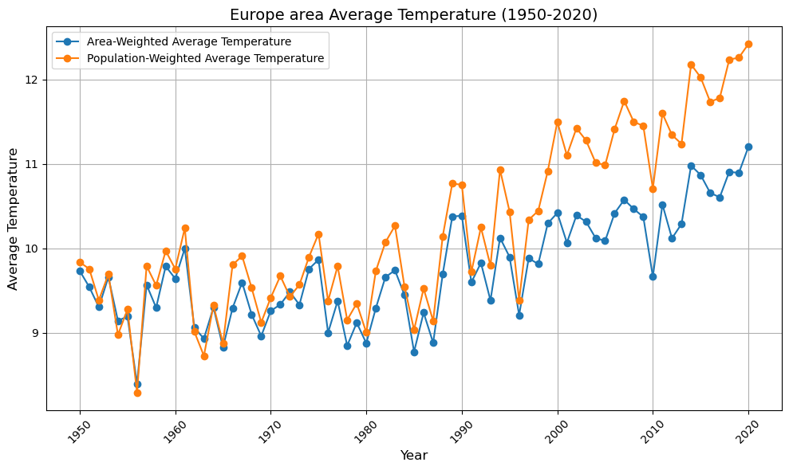

```python
import matplotlib.pyplot as plt

plt.figure(figsize=(10, 6))
plt.plot(t2m_europe_yearly_mean_area_weighted.valid_time.dt.year, t2m_europe_yearly_mean_area_weighted, marker='o', label='Area-Weighted Average Temperature')
plt.plot(t2m_europe_yearly_mean_population_weighted.year, t2m_europe_yearly_mean_population_weighted, marker='o', label='Population-Weighted Average Temperature')
plt.legend()
plt.title("Europe area Average Temperature (1950-2020)", fontsize=14)
plt.xlabel("Year", fontsize=12)
plt.ylabel("Average Temperature", fontsize=12)
plt.grid(True)
plt.xticks(rotation=45)
plt.tight_layout()
plt.show()
```